# DE analysis

2024-11-29

# 1 Background

We cleaned the clinical files metadata. Now we analyzed the NPX data generated. For the initial part, focus on the DE on the discovery dataset. Then move to the validation dataset

# 2 Objectives

1. Exploratory analysis
2. Perform DE with t-test
3. Perform DE with Wilcoxon rank sum test
4. Perform DE with linear model t-test
5. Compare the DE from methods
6. Overlap with cell surface markers

# 3 Conclusion

We will use the limma method for DE testing.

# 4 Pre-processing

## 4.1 Loading packages

```r
library(here)
library(tidyverse)
library(readxl)
library(readr)
library(stringr)
library(limma)

library(tidyverse)
library(ggplot2)
library(ggrepel)
library(gghighlight)
library(ggbeeswarm)
library(ggsignif)
library(VennDiagram)
library(ggvenn)
library(ggpubr)

library(OlinkAnalyze) # install.packages("OlinkAnalyze")
library(paletteer)
```

## 4.2 Directories

```r
set.seed(1234)
wd <- list()
wd$main <- here()
wd$data <- file.path(wd$main, "data")
wd$manishData <- file.path(wd$data, "raw/data_fromManish")
wd$d2024 <- file.path(wd$data, "updated_2024")
wd$d2024_npx <- file.path(wd$d2024, "NPX_data")
wd$output <- file.path(wd$main, "output")
wd$script <- file.path(wd$main, "scripts")

wd$outData <- file.path(wd$output, "data")
wd$outCurr <- file.path(wd$output, "02_DE")
```

Create directories

```r
if (!file.exists(wd$outCurr)) {
  dir.create(wd$outCurr)
} else {
  print("Directory already exists")
}
```

```
## [1] "Directory already exists"
```

Load functions

```r
source(file.path(wd$script, "functions.R"))
```

## 4.3 Load data

Load the processed metadata file

```r
load(file.path(wd$outData, "01_Metadata.Rdata"))
```

## 4.4 Survival metadata

We need a date for the OS. The OS for each patient is calculated by subtracting the sample collection date to death date. We censor patients who have missing death date (presumed alive) by the last follow up date.

```r
censor_date <- as.Date('2024-11-14') # November 14, 2024
```

### 4.4.1 Psomagen

We remind ourself of the psomagen clinical sheet.

> In the Psomagen cohort, some samples were profiled serially. The excel file contains 2 sheets related the Psomagen cohort, sheets 2 & 3.

> Sheet 2 contains only the unique patients IDs per row. It contains all the clinical data, eg - surgery, PSA values, tumor stage, date of death…etc.

> While Sheet 3 have the same number of rows as the NPX data. In sheet 3, the same patient with multiple timepoints is represented in multiple rows. There is a column `sample_id` that links to the NPX `sampleID`.

```r
# Two clicnial sheets
ps_clin.1 <- read_xlsx(meta_file, sheet = 2)
ps_clin.2 <- read_xlsx(meta_file, sheet = 3)
```

We can obtain the patient identifier, death date, deceased status from sheet 2.

```r
# Read in the Psomagen metadata
meta_psom <- ps_clin.1 %>%
  select('sample_id', 'MRN (UUHSC)', 'Death date', 'Deceased?', 'Sample1_date',
         'sample1_psa','sample1_ldh', 'sample1_alk_phos') %>%
  rename(mrn = 'MRN (UUHSC)',
         death_date = 'Death date',
         death = 'Deceased?',
         collection_date = 'Sample1_date',
         psa = 'sample1_psa',
         ldh = 'sample1_ldh',
         alk_ph = 'sample1_alk_phos')

# Censor the date
meta_psom$death_date[is.na(meta_psom$death_date)] <- censor_date

# Calulate OS in months
meta_psom <- meta_psom %>%
  mutate(OS = as.numeric(difftime(death_date, collection_date, units = "days")),
         OS = round(OS/30.417, digit=2),
         death = case_when(death == "No" ~ 0,
                           death == "Yes" ~ 1),
         sample_id = as.character(sample_id))
```

# 5 Obj 1: Exploratory analysis

## 5.1 PCA

```r
meta_psom_tmp <- meta_psom %>% select(-sample_id)

df_meta <- df_pre_post_ori %>%
  filter(!is.na(sample_id_psom)) %>%
  dplyr::rename(SampleID = sample_id_psom) %>%
  select(mrn, cohort, SampleID, txt_stat) %>%
  distinct() %>%
  mutate(SampleID = as.character(SampleID)) %>%
  left_join(meta_psom_tmp)
# This removes control samples as well
dat1_NPX_anno <- dat_NPX %>%
  mutate(SampleID = as.character(SampleID)) %>%
  dplyr::left_join(df_meta) %>%
  filter(!is.na(cohort))
```

Quick PCA

```
## 9 assay(s) exhibited assay QC warning. For more information see the Assay_Warning column.
```

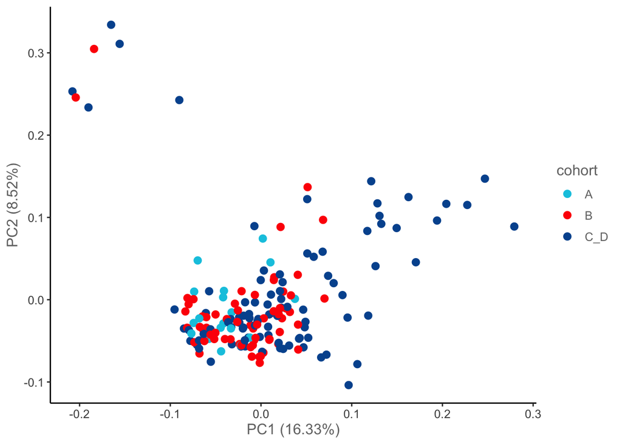

```r
p_pca <-
  dat1_NPX_anno %>%
  filter(!str_detect(SampleID, 'CS')) %>%
  olink_pca_plot(df = .,
                 color_g = "cohort", byPanel = FALSE, quiet = FALSE)
```

```r
pca_cor <- p_pca[[1]]$data %>%
  rename(PC1 = PCX,
         PC2 = PCY) %>%
  #Combine with master annotation
  left_join(df_meta)
```

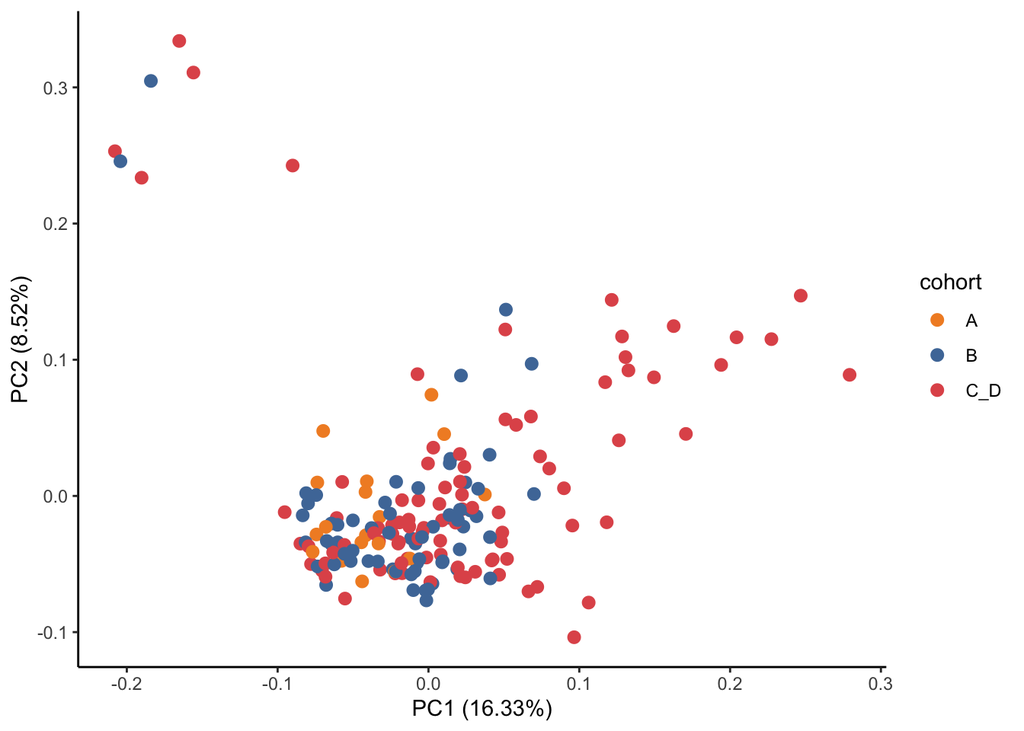

```r
ggplot(pca_cor, aes(x=PC1, y=PC2, colour=cohort)) +
  geom_point(size=2.5) +
  ylab(p_pca[[1]]$labels$y) +
  xlab(p_pca[[1]]$labels$x) +
  theme_classic() +
  theme(legend.position = "right",
        panel.grid.major = element_line(linetype = "blank"),
        panel.grid.minor = element_line(linetype = "blank")) +
  scale_colour_manual(values=pal.cohort) +
  NULL
```

Get the PCA coordinates

```r
pca_cor <- p_pca[[1]]$data %>%
  rename(PC1 = PCX,
         PC2 = PCY) %>%
  #Combine with master annotation
  left_join(df_meta)
```

Plot a different colour

```r
p3 <-
ggplot(pca_cor, aes(x=PC1, y=PC2, fill=cohort)) +
  geom_point(shape=21, size=3) +
  ylab(p_pca[[1]]$labels$y) +
  xlab(p_pca[[1]]$labels$x) +
  theme_classic() +
  theme(legend.position = "right",
        panel.grid.major = element_line(linetype = "blank"),
        panel.grid.minor = element_line(linetype = "blank")) +
  scale_fill_manual(values=pal.cohort.n) +
  NULL



ggsave(p3, file=file.path(wd$outCurr, "PCA_discovery.pdf"), height = 5, width = 7)
```

Colour based on some other variable

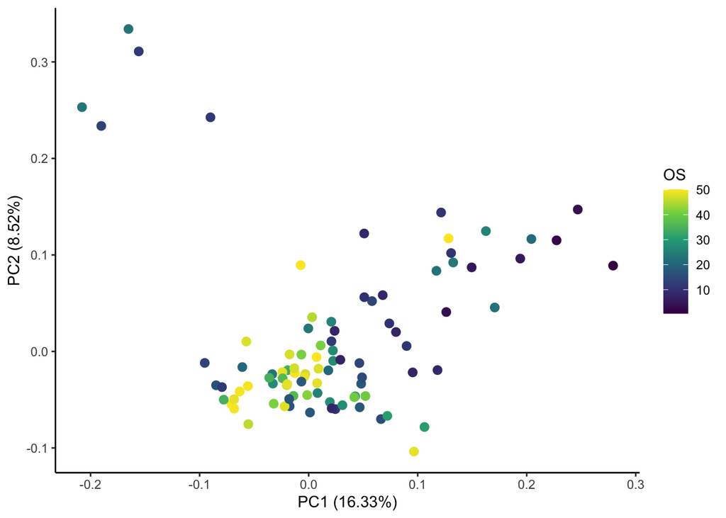

```r
pca_cor %>% filter(cohort == "C_D") %>%
ggplot(., aes(x=PC1, y=PC2, colour=OS)) +
  geom_point(size=2.5) +
  ylab(p_pca[[1]]$labels$y) +
  xlab(p_pca[[1]]$labels$x) +
  theme_classic() +
  theme(legend.position = "right",
        panel.grid.major = element_line(linetype = "blank"),
        panel.grid.minor = element_line(linetype = "blank")) +
  scale_colour_viridis_c() +
  NULL
```

## 5.2 Sample outlier

We check if any samples were considered outlier in all of the 8 panels

```r
outliers_qc_labeled <- dat1_NPX_anno |>
  olink_qc_plot(outlierLines = FALSE, label_outliers = TRUE)
```

```
## 9 assay(s) exhibited assay QC warning. For more information see the Assay_Warning column.
```

```r
dat_outlier <- outliers_qc_labeled$data


sam_outlier <- dat_outlier %>% group_by(SampleID, Outlier) %>%
  count() %>%
  filter(Outlier == 1) %>%
  arrange(desc(n))
head(sam_outlier)
```

```
## # A tibble: 6 × 3
## # Groups:   SampleID, Outlier [6]
##   SampleID Outlier     n
##   <chr>      <dbl> <int>
## 1 152            1     7
## 2 16             1     7
## 3 167            1     5
## 4 39             1     3
## 5 161            1     2
## 6 34             1     2
```

> No sample failed in all 8 panel. So we retain everything

## 5.3 Assay outlier

We want to check if any proteins needs to be excluded. Olink provides a collumn called “QC_Warning” that we can use to determine.

```r
warn_assay <- dat1_NPX_anno %>% filter(Assay_Warning == "WARN") %>% select(Assay, OlinkID) %>% distinct()
```

Or we can determine what number of samples are expressing the protein above the limit of detection

```r
numSample1 <- length(unique(dat1_NPX_anno$SampleID))

dat1_missing <- dat1_NPX_anno %>%
  group_by(OlinkID) %>%
  summarise(PercMissing = (sum(NPX < LOD) / numSample1) * 100) %>%
  mutate(Group = "Psomagen")
```

Lets retain all the proteins with less than 80% missing-ness

```r
assay_keep <- dat1_missing %>%
  filter(PercMissing <= 80)  %>%
  filter(!OlinkID %in% warn_assay$OlinkID)
length(unique(assay_keep$OlinkID))
```

```
## [1] 2384
```

Lets subset the NPX data frame to these proteins

```r
dat1_final <- dat1_NPX_anno %>%
  filter(OlinkID %in% assay_keep$OlinkID)
```

Sanity check

```r
length(unique(dat1_NPX_anno$OlinkID))
```

```
## [1] 2943
```

```r
length(unique(dat1_final$OlinkID))
```

```
## [1] 2384
```

## 5.4 PCA

Replot the PCA based on the filtered proteins

```
## 0 assay(s) exhibited assay QC warning. For more information see the Assay_Warning column.
```

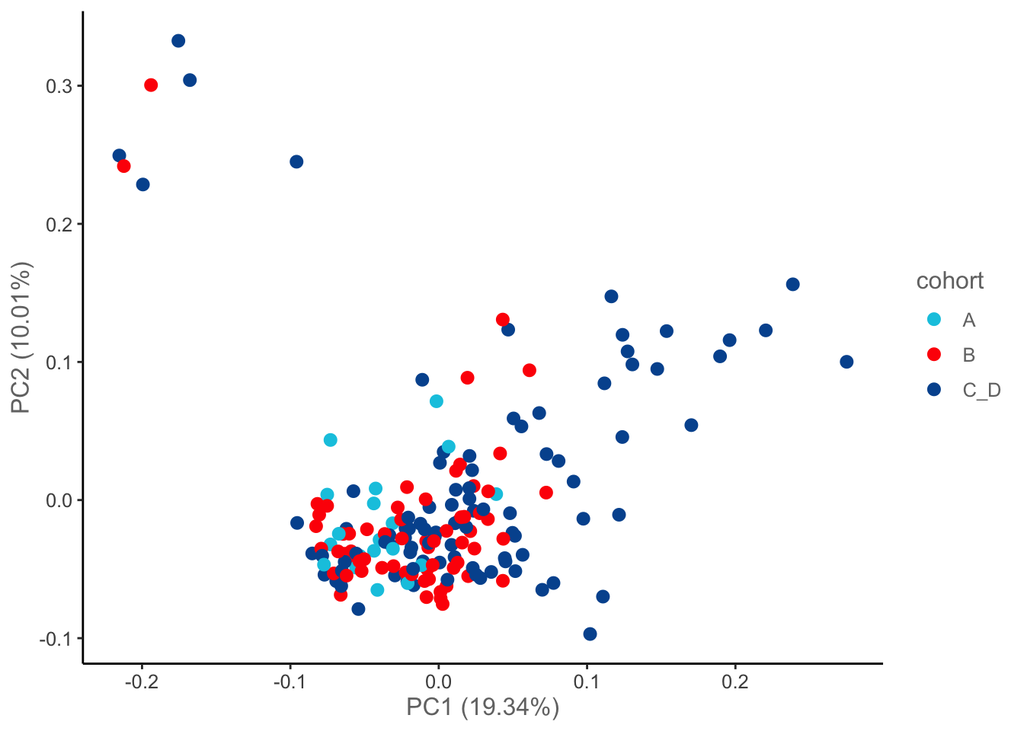

```r
#ss <- df_meta %>% filter(txt_stat %in% c("Pre", "Pre2"))
#dat1_final_tmp <- dat1_final %>% filter(SampleID %in% ss$SampleID)
# Quick PCA
p_pca <-
  dat1_final %>%
  filter(!str_detect(SampleID, 'CS')) %>%
  olink_pca_plot(df = .,
                 color_g = "cohort", byPanel = FALSE, quiet = FALSE)
```

```r
pca_cor <- p_pca[[1]]$data %>%
  rename(PC1 = PCX,
         PC2 = PCY) %>%
  #Combine with master annotation
  left_join(df_meta)
```

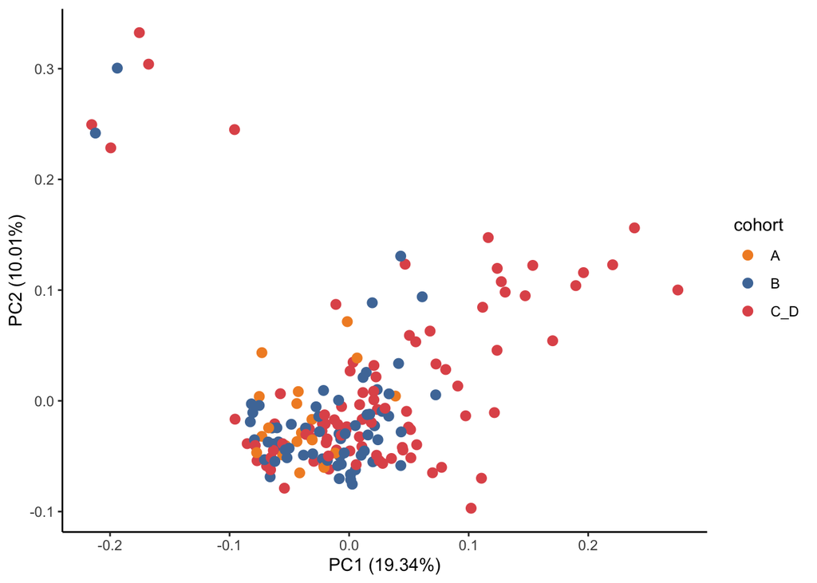

```r
ggplot(pca_cor, aes(x=PC1, y=PC2, colour=cohort)) +
  geom_point(size=2.5) +
  ylab(p_pca[[1]]$labels$y) +
  xlab(p_pca[[1]]$labels$x) +
  theme_classic() +
  theme(legend.position = "right",
        panel.grid.major = element_line(linetype = "blank"),
        panel.grid.minor = element_line(linetype = "blank")) +
  scale_colour_manual(values=pal.cohort) +
  NULL
```

```r
# Get the PCA coordinates
pca_cor <- p_pca[[1]]$data %>%
  rename(PC1 = PCX,
         PC2 = PCY) %>%
  #Combine with master annotation
  left_join(df_meta)
```

```r
p3 <-
ggplot(pca_cor, aes(x=PC1, y=PC2, fill=cohort)) +
  geom_point(shape=21, size=3) +
  ylab(p_pca[[1]]$labels$y) +
  xlab(p_pca[[1]]$labels$x) +
  theme_classic() +
  theme(legend.position = "right",
        panel.grid.major = element_line(linetype = "blank"),
        panel.grid.minor = element_line(linetype = "blank")) +
  scale_fill_manual(values=pal.cohort.n) +
  NULL



ggsave(p3, file=file.path(wd$outCurr, "PCA_discovery.pdf"), height = 5, width = 7)
```

### 5.4.1 PCA association

Try to see if there is associateion between PC1 and OS

```r
exp <- dat1_final %>%
  dplyr::select(SampleID, OlinkID, NPX) %>%
  # Remove contraol samples
  dplyr::filter(!str_detect(SampleID, 'CONTROL_SAMPLE')) %>%
  # Convert to wide
  tidyr::pivot_wider(names_from = SampleID, values_from = NPX) %>%
  as.data.frame()
rownames(exp) <- exp$OlinkID
exp <- exp[,-1]

pc <- prcomp(t(exp), scale. = TRUE)

pc1_scores <- pc$x[, 1]  # First principal component

cor(pc1_scores, df_meta$OS, method = "pearson")
```

```
## [1] 0.01342037
```

```r
summary(lm(pc$x[,1] ~ df_meta$OS))
```

```
##
## Call:
## lm(formula = pc$x[, 1] ~ df_meta$OS)
##
## Residuals:
##     Min      1Q  Median      3Q     Max
## -61.177 -12.587  -1.324   9.093  78.925
##
## Coefficients:
##             Estimate Std. Error t value Pr(>|t|)
## (Intercept) -0.66825    4.10863  -0.163    0.871
## df_meta$OS   0.01953    0.11032   0.177    0.860
##
## Residual standard error: 21.53 on 174 degrees of freedom
## Multiple R-squared:  0.0001801,  Adjusted R-squared:  -0.005566
## F-statistic: 0.03134 on 1 and 174 DF,  p-value: 0.8597
```

# 6 Obj 2: t-test

Lets run DE using one-sided (greater) t-test to find stage specific proteins

```r
# Make a 2-factor comparison for t-test
dat_NPX <- dat1_final %>%
  dplyr::mutate(
    Index = SampleID,
    cohort2 = cohort,
    c_a_vs_b = case_when(cohort2 == "A" ~ "Y", cohort2 == "B" ~ "N"),
    c_a_vs_cd = case_when(cohort2 == "A" ~ "Y", cohort2 == "C_D" ~ "N"),

    #c_b = case_when(cohort_simple == "B" ~ "Y", TRUE ~ "N"),
    c_b_vs_a = case_when(cohort2 == "B" ~ "Y", cohort2 == "A" ~ "N"),
    c_b_vs_cd = case_when(cohort2 == "B" ~ "Y", cohort2 == "C_D" ~ "N"),

    #c_cd = case_when(cohort_simple == "C" ~ "Y", TRUE ~ "N"),
    c_cd_vs_a = case_when(cohort2 == "C_D" ~ "Y", cohort2 == "A" ~ "N"),
    c_cd_vs_b = case_when(cohort2 == "C_D" ~ "Y", cohort2 == "B" ~ "N")
  )

sel_cat <- dat_NPX %>% dplyr::select(c_a_vs_b:c_cd_vs_b) %>% colnames()

# Need to remove Assay with NA - function has been adopted

p_list <- list()

for (i in seq_along(sel_cat)){
  t.tes_res <- t.test_cat_col2(dat_NPX, sel_cat[i])

  p_list[[i]]  <- t.tes_res
}
```

```
## [1] "t-test on c_a_vs_b"
```

```
## Samples removed due to missing variable levels: 1, 3, 4, 6, 7, 10, 12, 13, 14, 16, 17, 22, 23, 28, 30, 33, 34, 35, 36, 39, 40, 42, 45, 46, 47, 48, 49, 51, 55, 56, 57, 58, 59, 60, 68, 69, 70, 73, 75, 79, 80, 83, 84, 87, 88, 89, 93, 97, 98, 100, 101, 102, 103, 104, 105, 106, 107, 108, 109, 111, 112…
```

```
## Variable converted from character to factor: c_a_vs_b
```

```
## T-test is performed on N - Y.
```

```
## [1] "t-test on c_a_vs_cd"
```

```
## Samples removed due to missing variable levels: 2, 5, 8, 11, 15, 18, 19, 20, 21, 25, 27, 29, 31, 32, 37, 38, 41, 43, 44, 50, 52, 61, 62, 63, 64, 65, 66, 67, 71, 72, 74, 76, 77, 78, 81, 82, 85, 86, 90, 94, 96, 99, 110, 115, 116, 122, 123, 126, 130, 138, 141, 150, 151, 153, 154, 155, 156, 157, 161,…
## Variable converted from character to factor: c_a_vs_cd
```

```
## [1] "t-test on c_b_vs_a"
```

```
## Samples removed due to missing variable levels: 1, 3, 4, 6, 7, 10, 12, 13, 14, 16, 17, 22, 23, 28, 30, 33, 34, 35, 36, 39, 40, 42, 45, 46, 47, 48, 49, 51, 55, 56, 57, 58, 59, 60, 68, 69, 70, 73, 75, 79, 80, 83, 84, 87, 88, 89, 93, 97, 98, 100, 101, 102, 103, 104, 105, 106, 107, 108, 109, 111, 112…
## Variable converted from character to factor: c_b_vs_a
```

```
## [1] "t-test on c_b_vs_cd"
```

```
## Samples removed due to missing variable levels: 9, 24, 26, 53, 54, 91, 92, 95, 117, 118, 120, 133, 135, 144, 147, 148, 158, 163, 169
## Variable converted from character to factor: c_b_vs_cd
```

```
## [1] "t-test on c_cd_vs_a"
```

```
## Samples removed due to missing variable levels: 2, 5, 8, 11, 15, 18, 19, 20, 21, 25, 27, 29, 31, 32, 37, 38, 41, 43, 44, 50, 52, 61, 62, 63, 64, 65, 66, 67, 71, 72, 74, 76, 77, 78, 81, 82, 85, 86, 90, 94, 96, 99, 110, 115, 116, 122, 123, 126, 130, 138, 141, 150, 151, 153, 154, 155, 156, 157, 161,…
## Variable converted from character to factor: c_cd_vs_a
```

```
## [1] "t-test on c_cd_vs_b"
```

```
## Samples removed due to missing variable levels: 9, 24, 26, 53, 54, 91, 92, 95, 117, 118, 120, 133, 135, 144, 147, 148, 158, 163, 169
## Variable converted from character to factor: c_cd_vs_b
```

```r
p_list_base <- p_list

df_de_bridge <- do.call(rbind, p_list_base) %>%
  mutate(log2FC = round(log2FC, 1))
```

Show an example gene to get context

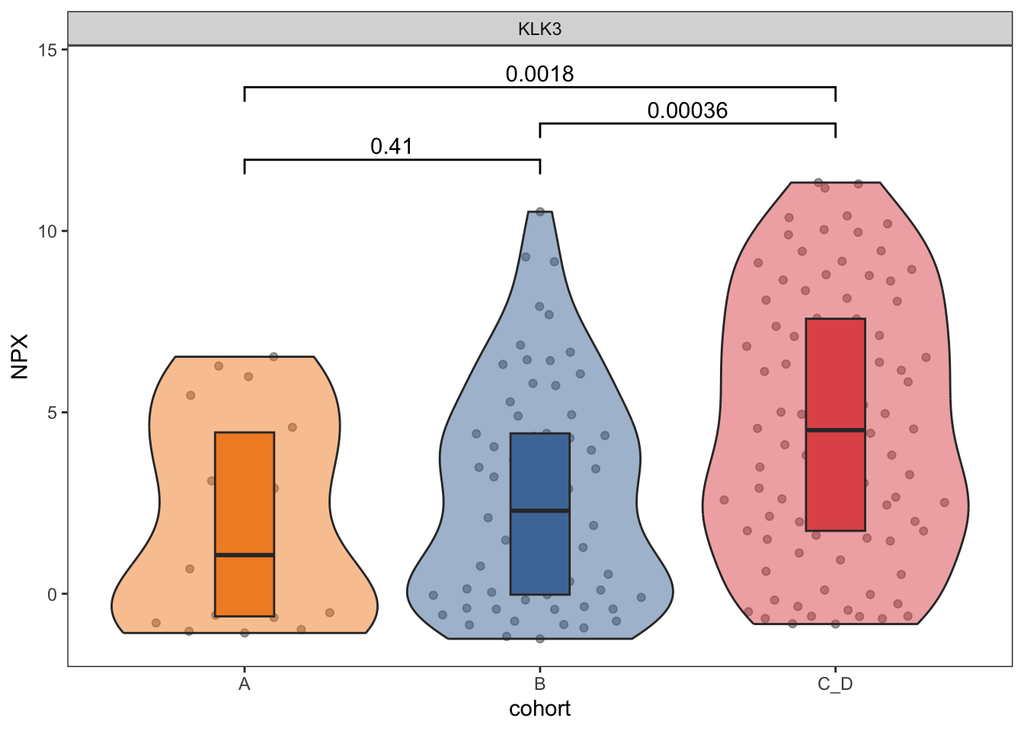

```r
# NOTE - if want to find the over expressed proteins in one of the category, the category group of interest should be at the back. Eg - c_b_vs_cd" means we are interested in looking at over-expressed proteins in "cd" group compared to "b".

ll <- df_de_bridge %>% filter(Cat == "c_b_vs_cd") %>% pull(OlinkID) %>% head()

xxx <- df_de_bridge %>% filter(Cat == "c_b_vs_cd") %>%
  dplyr::arrange(desc(log2FC))

df_plot <- dat_NPX %>%
  dplyr::filter(OlinkID %in% xxx$OlinkID[1])

# Show the plot
max_y <- max(df_plot$NPX)
min_y <- min(df_plot$NPX)

p_viol_gene <-
  df_plot %>%
  ggplot(aes(x = cohort, y = NPX, fill = cohort)) +
  geom_quasirandom(dodge.width=0.9, colour="grey30", alpha=0.5) +
  geom_violin(alpha = 0.5, scale = "width", position = position_dodge(width = 0.9)) +
  geom_boxplot(outlier.alpha = 0,  width = 0.2, coef=0,
               position = position_dodge(width = 0.9)) +
  scale_fill_manual(values=unique(pal.cohort)) +
  theme_bw() +
  theme(legend.position = "none",
        panel.grid.major = element_line(linetype = "blank"),
        panel.grid.minor = element_line(linetype = "blank"),
        axis.text.x = element_text(angle = 0)) +
  facet_wrap(~Assay, ncol=6, scales = "free_y") +
  geom_signif(
    comparisons = list(c("A", "B"),
                       c("B", "C_D"),
                       c("A", "C_D")),
    map_signif_level = FALSE,
    test = "t.test",
    y_position = c(max_y, max_y+1, max_y+2)
  ) +
  scale_y_continuous(limits=c(min_y, max_y+3)) +
  NULL
p_viol_gene
```

Show expression on PCA plot

```r
g_exp <- df_plot %>%
  select(SampleID, NPX, Assay)

pca_cor_exp <- pca_cor %>% left_join(g_exp)

ggplot(pca_cor_exp, aes(x=PC1, y=PC2, colour=NPX)) +
  geom_point(size=2.5) +
  ylab(p_pca[[1]]$labels$y) +
  xlab(p_pca[[1]]$labels$x) +
  theme_classic() +
  theme(legend.position = "right",
        panel.grid.major = element_line(linetype = "blank"),
        panel.grid.minor = element_line(linetype = "blank")) +
  scale_colour_viridis_c() +
  ggtitle(unique(g_exp$Assay))+
  NULL
```

Find the significant proteins based on the overlap

```r
cut_bfc <- 1.2 # Base fold change cut-off
cut_logFC <- 0.4 # Log FC cut-iff
cut_fdr <- 0.05

# Protein specific to A
df_cat_a <- df_de_bridge %>%
  #filter(Cat %in% c("c_b_vs_a", "c_cd_vs_a") & Adjusted_pval <= cut_fdr)
  filter(Cat %in% c("c_b_vs_a", "c_cd_vs_a") & Adjusted_pval <= cut_fdr & log2FC >= cut_logFC)

df_cat_b <- df_de_bridge %>%
  #filter(Cat %in% c("c_a_vs_b", "c_cd_vs_b") & Adjusted_pval <= cut_fdr)
  filter(Cat %in% c("c_a_vs_b", "c_cd_vs_b") & Adjusted_pval <= cut_fdr & log2FC >= cut_logFC)

df_cat_cd <- df_de_bridge %>%
  #filter(Cat %in% c("c_a_vs_cd", "c_b_vs_cd") & Adjusted_pval <= cut_fdr)
  filter(Cat %in% c("c_a_vs_cd", "c_b_vs_cd") & Adjusted_pval <= cut_fdr & log2FC >= cut_logFC)


un_a <- unique(df_cat_a$OlinkID)
un_b <- unique(df_cat_b$OlinkID)
un_cd <- unique(df_cat_cd$OlinkID)

l_uniq <- unique(c(un_a, un_b, un_cd))

l_all <- list(
  A = un_a,
  B = un_b,
  C = un_cd
)


overlap <- calculate.overlap(
x <- list("Group A"=un_a,
          "Group B"=un_b,
          "Group CD"=un_cd))

pdf(file=file.path(wd$outCurr, "DE_venn_overlap.pdf"), width = 5, height = 5)
ggvenn(
  x,
  fill_color = pal.cohort.n2,
  show_percentage = FALSE,
  stroke_size = 0.5, set_name_size = 4
)
dev.off()
```

```r
ggvenn(
  x,
  fill_color = pal.cohort.n2,
  show_percentage = FALSE,
  stroke_size = 0.5, set_name_size = 4
)
```

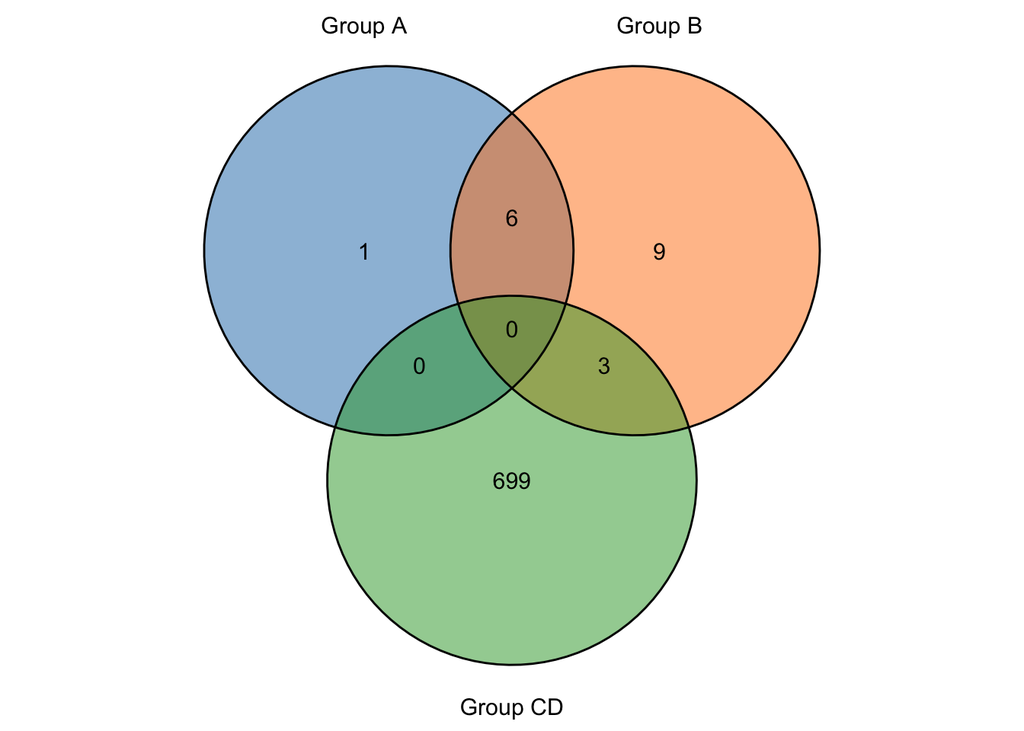

Get data frame

```r
# Combine all lists into a single data frame
all_elements <- unique(c(un_a, un_b, un_cd)) # All unique elements

# Function to determine overlap degree for each element
get_overlap_degree <- function(element, groups) {
  present_in <- names(groups)[sapply(groups, function(group) element %in% group)]
  if (length(present_in) > 1) {
    return(paste(present_in, collapse = " and ")) # Combine groups if in multiple
  } else if (length(present_in) == 1) {
    return(present_in) # Only in one group
  } else {
    return("None") # Should not happen in typical use cases
  }
}

# Apply the function across all elements
overlap_degree <- sapply(all_elements, function(x) get_overlap_degree(x, list("Group A" = un_a, "Group B" = un_b, "Group CD" = un_cd)))

# Create final data frame
overlap_df <- data.frame(
  OlinkID = all_elements,
  OverlapDegree = overlap_degree
) %>% left_join(df_id_pro)
write.csv(overlap_df, file.path(wd$outCurr, "DE_genes_t_test.csv"))
```

# 7 Obj 3: Wilcoxon rank sum

We check the data normality distribution

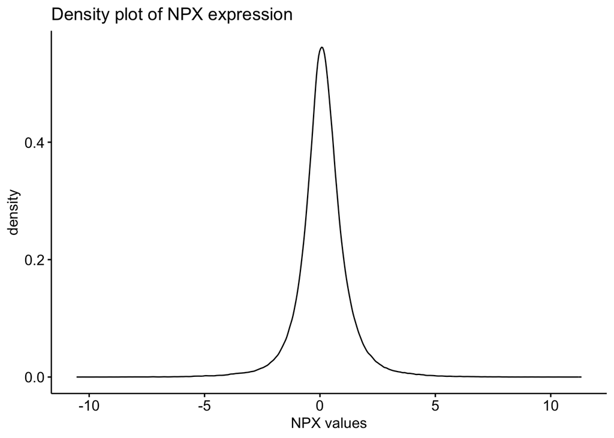

```r
ggdensity(dat1_final$NPX,
          main = "Density plot of NPX expression",
          xlab = "NPX values")
```

> Visually inspecting the data shows that it is normally distributed.

Just run Wilcoxon rank sum test anyway

```r
p_list <- list()

for (i in seq_along(sel_cat)){
  t.tes_res <- wilcox_cat_col2(dat_NPX, sel_cat[i])

  p_list[[i]]  <- t.tes_res
}
```

```
## [1] "Wilcox test on c_a_vs_b"
```

```
## Samples removed due to missing variable levels: 1, 3, 4, 6, 7, 10, 12, 13, 14, 16, 17, 22, 23, 28, 30, 33, 34, 35, 36, 39, 40, 42, 45, 46, 47, 48, 49, 51, 55, 56, 57, 58, 59, 60, 68, 69, 70, 73, 75, 79, 80, 83, 84, 87, 88, 89, 93, 97, 98, 100, 101, 102, 103, 104, 105, 106, 107, 108, 109, 111, 112…
```

```
## Variable converted from character to factor: c_a_vs_b
```

```
## Mann-Whitney U Test is performed on N - Y.
```

```
## [1] "Wilcox test on c_a_vs_cd"
```

```
## Samples removed due to missing variable levels: 2, 5, 8, 11, 15, 18, 19, 20, 21, 25, 27, 29, 31, 32, 37, 38, 41, 43, 44, 50, 52, 61, 62, 63, 64, 65, 66, 67, 71, 72, 74, 76, 77, 78, 81, 82, 85, 86, 90, 94, 96, 99, 110, 115, 116, 122, 123, 126, 130, 138, 141, 150, 151, 153, 154, 155, 156, 157, 161,…
## Variable converted from character to factor: c_a_vs_cd
```

```
## [1] "Wilcox test on c_b_vs_a"
```

```
## Samples removed due to missing variable levels: 1, 3, 4, 6, 7, 10, 12, 13, 14, 16, 17, 22, 23, 28, 30, 33, 34, 35, 36, 39, 40, 42, 45, 46, 47, 48, 49, 51, 55, 56, 57, 58, 59, 60, 68, 69, 70, 73, 75, 79, 80, 83, 84, 87, 88, 89, 93, 97, 98, 100, 101, 102, 103, 104, 105, 106, 107, 108, 109, 111, 112…
## Variable converted from character to factor: c_b_vs_a
```

```
## [1] "Wilcox test on c_b_vs_cd"
```

```
## Samples removed due to missing variable levels: 9, 24, 26, 53, 54, 91, 92, 95, 117, 118, 120, 133, 135, 144, 147, 148, 158, 163, 169
## Variable converted from character to factor: c_b_vs_cd
```

```
## [1] "Wilcox test on c_cd_vs_a"
```

```
## Samples removed due to missing variable levels: 2, 5, 8, 11, 15, 18, 19, 20, 21, 25, 27, 29, 31, 32, 37, 38, 41, 43, 44, 50, 52, 61, 62, 63, 64, 65, 66, 67, 71, 72, 74, 76, 77, 78, 81, 82, 85, 86, 90, 94, 96, 99, 110, 115, 116, 122, 123, 126, 130, 138, 141, 150, 151, 153, 154, 155, 156, 157, 161,…
## Variable converted from character to factor: c_cd_vs_a
```

```
## [1] "Wilcox test on c_cd_vs_b"
```

```
## Samples removed due to missing variable levels: 9, 24, 26, 53, 54, 91, 92, 95, 117, 118, 120, 133, 135, 144, 147, 148, 158, 163, 169
## Variable converted from character to factor: c_cd_vs_b
```

```r
p_list_base <- p_list

df_de_wilcox <- do.call(rbind, p_list_base) %>%
  mutate(log2FC = round(log2FC, 1))
```

Repeat the steps above

```r
# Protein specific to A
df_cat_a <- df_de_wilcox %>%
  #filter(Cat %in% c("c_b_vs_a", "c_cd_vs_a") & Adjusted_pval <= cut_fdr)
  filter(Cat %in% c("c_b_vs_a", "c_cd_vs_a") & Adjusted_pval <= cut_fdr & log2FC >= cut_logFC)

df_cat_b <- df_de_wilcox %>%
  #filter(Cat %in% c("c_a_vs_b", "c_cd_vs_b") & Adjusted_pval <= cut_fdr)
  filter(Cat %in% c("c_a_vs_b", "c_cd_vs_b") & Adjusted_pval <= cut_fdr & log2FC >= cut_logFC)

df_cat_cd <- df_de_wilcox %>%
  #filter(Cat %in% c("c_a_vs_cd", "c_b_vs_cd") & Adjusted_pval <= cut_fdr)
  filter(Cat %in% c("c_a_vs_cd", "c_b_vs_cd") & Adjusted_pval <= cut_fdr & log2FC >= cut_logFC)


un_a <- unique(df_cat_a$OlinkID)
un_b <- unique(df_cat_b$OlinkID)
un_cd <- unique(df_cat_cd$OlinkID)

l_uniq <- unique(c(un_a, un_b, un_cd))

l_all <- list(
  A = un_a,
  B = un_b,
  C = un_cd
)


overlap <- calculate.overlap(
x <- list("Group A"=un_a,
          "Group B"=un_b,
          "Group CD"=un_cd))

pdf(file=file.path(wd$outCurr, "DE_venn_overlap_Wilcox.pdf"), width = 5, height = 5)
ggvenn(
  x,
  fill_color = pal.cohort.n2,
  show_percentage = FALSE,
  stroke_size = 0.5, set_name_size = 4
)
dev.off()
```

```r
ggvenn(
  x,
  fill_color = pal.cohort.n2,
  show_percentage = FALSE,
  stroke_size = 0.5, set_name_size = 4
)
```

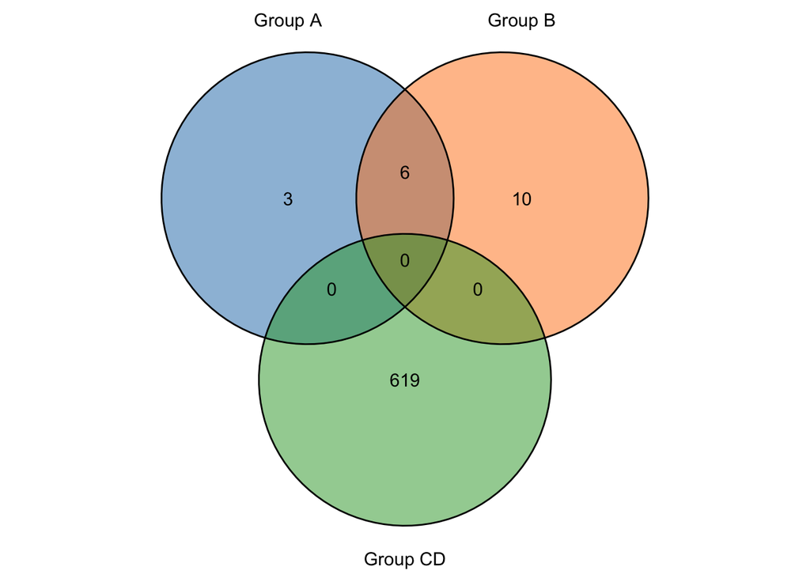

Compile into a list

```r
# Combine all lists into a single data frame
all_elements <- unique(c(un_a, un_b, un_cd)) # All unique elements

# Apply the function across all elements
overlap_degree <- sapply(all_elements, function(x) get_overlap_degree(x, list("Group A" = un_a, "Group B" = un_b, "Group CD" = un_cd)))

# Create final data frame
overlap_df_wilcox <- data.frame(
  OlinkID = all_elements,
  OverlapDegree = overlap_degree
) %>% left_join(df_id_pro)
write.csv(overlap_df_wilcox, file.path(wd$outCurr, "DE_genes_wilco.csv"))
```

# 8 Obj 4: Linear model t-test

We now use the linear model approach.

```r
# Limit to baseline (pre-treatment)
# #full_dat <- dat1_final
# tmp1 <- full_dat %>% dplyr::filter(cohort %in% c("B", "C_D") & txt_stat %in% c("Pre", "Pre2"))
# tmp2 <- full_dat %>% dplyr::filter(cohort %in% c("A"))
#
# dat1_final <- rbind(tmp1, tmp2)
# -----------------------
# 1) Generate to gene x sample matrix
# -----------------------
mat_all <- dat1_final %>%
  dplyr::select(SampleID, OlinkID, NPX) %>%
  # Remove contraol samples
  dplyr::filter(!str_detect(SampleID, 'CONTROL_SAMPLE')) %>%
  # Convert to wide
  tidyr::pivot_wider(names_from = SampleID, values_from = NPX) %>%
  as.data.frame()
rownames(mat_all) <- mat_all$OlinkID
mat_all <- mat_all[,-1]

# --------------------------------
# 2) Create design and contrasts
# --------------------------------
# Groups for each of the columns
df_group <- dat1_final %>% select(SampleID, cohort) %>% distinct()
identical(colnames(mat_all), df_group$SampleID)
```

```
## [1] TRUE
```

```r
group <- df_group$cohort

# Model matrix with no intercept (i.e., "0 + group" form)
design <- model.matrix(~ 0 + group)
colnames(design) <- c("A", "B", "C_D")

# Create two contrasts: A_vs_CD and B_vs_CD
# +ve fold change will be the one on the left
contrast.matrix <- makeContrasts(
  A_vs_CD = C_D - A,
  B_vs_CD = C_D - B,
  A_vs_B = B - A,
  levels   = design
)

# ------------------------------------------------------------
# 3) Fit linear model, apply contrasts, and get unfiltered topTable
# ------------------------------------------------------------
fit  <- lmFit(mat_all, design)
fit2 <- contrasts.fit(fit, contrast.matrix)
fit2 <- eBayes(fit2)

# Collect all results (no filtering) in a single data frame:
results_df <- data.frame()

for(i in seq_len(ncol(contrast.matrix))) {
  # Extract all genes (number=Inf), no sorting by p-value
  tt <- topTable(fit2, coef = i, number = Inf, sort.by = "none")

  # Add columns for clarity
  tt$Gene     <- rownames(tt)
  tt$Contrast <- colnames(contrast.matrix)[i]

  # Combine
  results_df <- rbind(results_df, tt)
}

# Print the final results data frame (unfiltered)
limma_df <- results_df %>%
  rename(OlinkID = Gene) %>%
  left_join(df_id_pro) %>%
  rename(Adjusted_pval = adj.P.Val,
         log2FC = logFC)
```

Get overlap

```r
# Protein specific to A
df_cat_a <- limma_df %>%
  #filter(Cat %in% c("c_b_vs_a", "c_cd_vs_a") & Adjusted_pval <= cut_fdr)
  filter(Contrast %in% c("A_vs_B", "A_vs_CD") & Adjusted_pval <= cut_fdr & log2FC <= -cut_logFC)

df_cat_b_1 <- limma_df %>%
  filter(Contrast %in% c("B_vs_CD") & Adjusted_pval <= cut_fdr & log2FC <= -cut_logFC)
df_cat_b_2 <- limma_df %>%
  filter(Contrast %in% c("A_vs_B") & Adjusted_pval <= cut_fdr & log2FC >= cut_logFC)

df_cat_b <- rbind(df_cat_b_1, df_cat_b_2)

df_cat_cd <- limma_df %>%
  #filter(Cat %in% c("c_a_vs_cd", "c_b_vs_cd") & Adjusted_pval <= cut_fdr)
  filter(Contrast %in% c("A_vs_CD", "B_vs_CD") & Adjusted_pval <= cut_fdr & log2FC >= cut_logFC)


un_a <- unique(df_cat_a$OlinkID)
un_b <- unique(df_cat_b$OlinkID)
un_cd <- unique(df_cat_cd$OlinkID)


overlap <- calculate.overlap(
x <- list("Group A"=un_a,
          "Group B"=un_b,
          "Group CD"=un_cd))

ggvenn(
  x,
  fill_color = pal.cohort.n2,
  show_percentage = FALSE,
  stroke_size = 0.5, set_name_size = 4
)
```

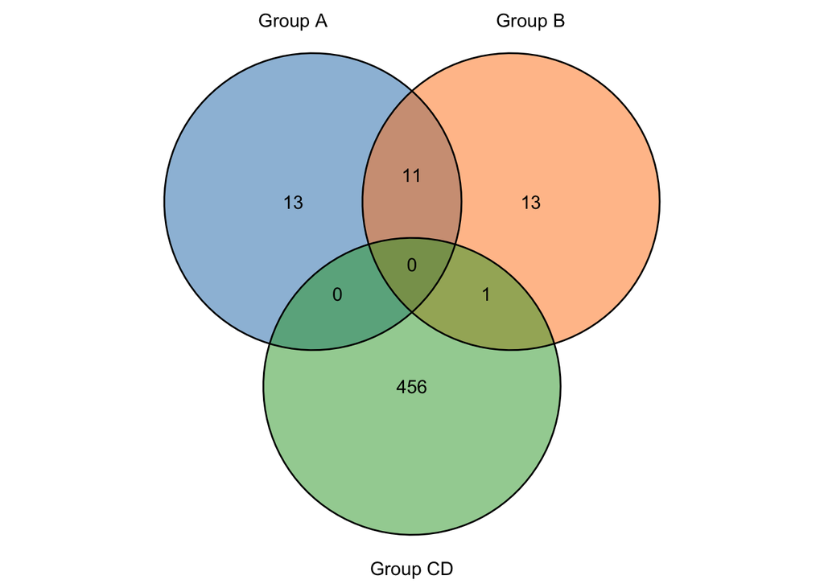

```r
pdf(file=file.path(wd$outCurr, "DE_venn_overlap_Limma.pdf"), width = 5, height = 5)
ggvenn(
  x,
  fill_color = pal.cohort.n2,
  show_percentage = FALSE,
  stroke_size = 0.5, set_name_size = 4
)
dev.off()
```

```r
# Protein defining cd stage only
cd_prot <- overlap$a7
```

Save the output

```r
# Combine all lists into a single data frame
all_elements <- unique(c(un_a, un_b, un_cd)) # All unique elements

# Apply the function across all elements
overlap_degree <- sapply(all_elements, function(x) get_overlap_degree(x, list("Group A" = un_a, "Group B" = un_b, "Group CD" = un_cd)))

# Create final data frame
overlap_df_limma <- data.frame(
  OlinkID = all_elements,
  OverlapDegree = overlap_degree
) %>% left_join(df_id_pro)
write.csv(overlap_df_limma, file.path(wd$outCurr, "DE_genes_limma.csv"))
```

## 8.1 DE table

Lets generate a table of the proteins to show their mean expression level, fold change and FDR.

```r
# Get the Mean expression in cohort A, B & C_D
tt <- df_de_bridge %>% select(OlinkID, Cat, Mean_Y, Mean_N) %>%
  filter(OlinkID %in% overlap_df_limma$OlinkID)

# Step 1: Extract group1 and group2 from 'Cat'
df_clean <- tt %>%
  mutate(
    group1 = str_extract(Cat, "(?<=c_)[^_]+"),
    group2 = str_extract(Cat, "(?<=vs_).*")
  )

# Step 2: Reshape to long format, linking Mean_Y to group1 and Mean_N to group2
df_long <- df_clean %>%
  select(OlinkID, group1, group2, Mean_Y, Mean_N) %>%
  pivot_longer(cols = c(Mean_Y, Mean_N), names_to = "type", values_to = "mean_value") %>%
  mutate(group = if_else(type == "Mean_Y", group1, group2)) %>%
  select(OlinkID, group, mean_value) %>%
  distinct()  # keep unique (OlinkID, group, mean) pairs

# Step 3: Pivot to wide format
df_wide <- df_long %>%
  pivot_wider(names_from = group, values_from = mean_value)
```

For each of the Olink ID add the fold change, p-value and FDR as determined by limma

```r
# Step 1: pivot longer to put all numeric columns under one column with names
df2_long <- limma_df %>%
  filter(OlinkID %in% overlap_df_limma$OlinkID) %>%
  select(OlinkID, Contrast, log2FC, t, P.Value, Adjusted_pval) %>%
  pivot_longer(cols = c(log2FC, t, P.Value, Adjusted_pval),
               names_to = "metric", values_to = "value")

# Step 2: unite metric and contrast for column names
df2_wide <- df2_long %>%
  mutate(name = paste0(metric, "_", Contrast)) %>%
  select(-metric, -Contrast) %>%
  pivot_wider(names_from = name, values_from = value)
```

Join both of them with the overlap data

```r
overlap_df_limma_full <- overlap_df_limma %>%
  left_join(df_wide) %>%
  left_join(df2_wide) %>%
  arrange(OverlapDegree, Assay)
write.csv(overlap_df_limma_full, file.path(wd$outCurr, "DE_genes_limma_with_pVal.csv"))
```

## 8.2 Breakdown

Since the comparison is to get the proteins overexpressed in CD state, it can be from comparing A vs CD or B vs CD. Lets get the counts based on the category

```r
pivot_table <- limma_df %>%
  filter(Contrast %in% c("A_vs_CD", "B_vs_CD")) %>%
  filter (Adjusted_pval  <= cut_fdr & log2FC >= cut_logFC) %>%
  filter(OlinkID %in% overlap$a7) %>%
  select(OlinkID, Assay, Contrast) %>%
  mutate(present = 1) %>%  # Add a column to indicate presence
  pivot_wider(names_from = Contrast, values_from = present, values_fill = list(present = 0))

summary_cat <- pivot_table %>%
  mutate(category = case_when(
    A_vs_CD == 1 & B_vs_CD == 0 ~ "A_vs_CD only",
    A_vs_CD == 0 & B_vs_CD == 1 ~ "B_vs_CD only",
    A_vs_CD == 1 & B_vs_CD == 1 ~ "Both A_vs_CD and B_vs_CD",
    TRUE ~ "Other"
  ))
summary_counts <- summary_cat %>% count(category)
```

We shot the plot of the top proteins

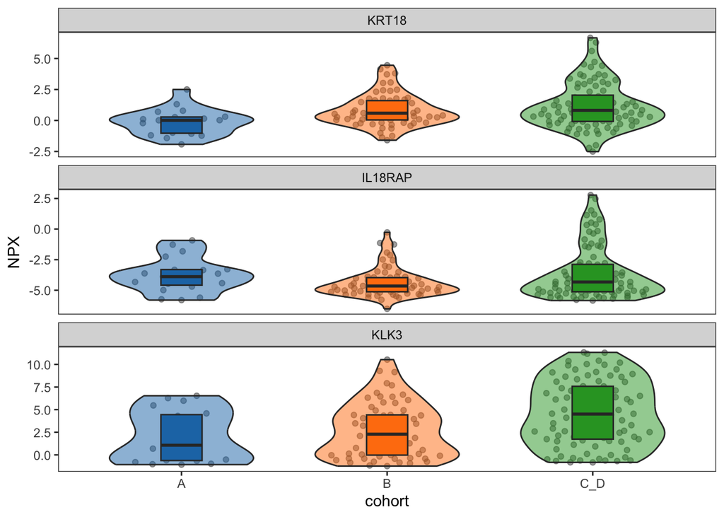

```r
tt <- limma_df %>%
  filter(Contrast %in% c("A_vs_CD", "B_vs_CD")) %>%
  filter (Adjusted_pval  <= cut_fdr & log2FC >= cut_logFC) %>%
  filter(OlinkID %in% overlap$a7)

t1 <- summary_cat %>% filter(category == "A_vs_CD only")
top_a <- tt %>% filter(OlinkID %in% t1$OlinkID) %>%
  slice_max(log2FC, n=1, with_ties = FALSE)
#slice_min(Adjusted_pval, n=1, with_ties = FALSE)

t1 <- summary_cat %>% filter(category == "B_vs_CD only")
top_b <- tt %>% filter(OlinkID %in% t1$OlinkID) %>%
  slice_max(log2FC, n=10, with_ties = FALSE)
#slice_min(Adjusted_pval, n=1, with_ties = FALSE)

t1 <- summary_cat %>% filter(category == "Both A_vs_CD and B_vs_CD")
top_both <- tt %>% filter(OlinkID %in% t1$OlinkID) %>%
  slice_max(log2FC, n=1, with_ties = FALSE)
#slice_min(Adjusted_pval, n=1, with_ties = FALSE)

# Generate the plot
top_pro <- c(top_a$OlinkID, top_b$OlinkID[6], top_both$OlinkID)
top_ass <- c(top_a$Assay, top_b$Assay[6], top_both$Assay)
df_plot <- dat_NPX %>%
  dplyr::filter(OlinkID %in% top_pro) %>%
  mutate(Assay = factor(Assay, levels = (top_ass)))

# Show the plot
max_y <- max(df_plot$NPX)
min_y <- min(df_plot$NPX)

p_viol_gene <-
  df_plot %>%
  ggplot(aes(x = cohort, y = NPX, fill = cohort)) +
  geom_quasirandom(dodge.width=0.1, width = 0.3, colour="grey30", alpha=0.5) +
  geom_violin(alpha = 0.5, scale = "width", width=0.7, position = position_dodge(width = 0.9)) +
  geom_boxplot(outlier.alpha = 0,  width = 0.2, coef=0,
               position = position_dodge(width = 0.9)) +
  scale_fill_manual(values=unique(pal.cohort.n2)) +
  theme_bw() +
  theme(legend.position = "none",
        panel.grid.major = element_line(linetype = "blank"),
        panel.grid.minor = element_line(linetype = "blank"),
        axis.text.x = element_text(angle = 0)) +
  facet_wrap(~Assay, ncol=1, scales = "free_y") +
  #scale_y_continuous(limits=c(min_y, max_y+3)) +
  NULL
p_viol_gene
```

```r
# Save plot
ggsave(p_viol_gene, file=file.path(wd$outCurr, "mCRPC_violin_categroies.pdf"), height = 7, width = 5)
```

Rather than a single gene, we can do a trend plot for all the genes

```r
tt <- limma_df %>%
  filter(Contrast %in% c("A_vs_CD", "B_vs_CD")) %>%
  filter (Adjusted_pval  <= cut_fdr & log2FC >= cut_logFC) %>%
  filter(OlinkID %in% overlap$a7)

t1 <- summary_cat %>% filter(category == "A_vs_CD only")
top_a <- tt %>% filter(OlinkID %in% t1$OlinkID)

t1 <- summary_cat %>% filter(category == "B_vs_CD only")
top_b <- tt %>% filter(OlinkID %in% t1$OlinkID)

t1 <- summary_cat %>% filter(category == "Both A_vs_CD and B_vs_CD")
top_both <- tt %>% filter(OlinkID %in% t1$OlinkID)
```

Now generate some plots

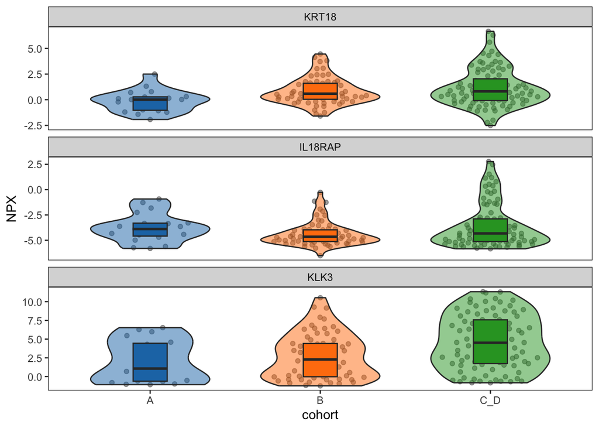

```r
# Plot a z-normlized
df_plot <- dat_NPX %>%
  dplyr::filter(OlinkID %in% top_pro) %>%
  mutate(Assay = factor(Assay, levels = (top_ass)))

# Show the plot
max_y <- max(df_plot$NPX)
min_y <- min(df_plot$NPX)

p_viol_gene <-
  df_plot %>%
  ggplot(aes(x = cohort, y = NPX, fill = cohort)) +
  geom_quasirandom(dodge.width=0.1, width = 0.3, colour="grey30", alpha=0.5) +
  geom_violin(alpha = 0.5, scale = "width", width=0.7, position = position_dodge(width = 0.9)) +
  geom_boxplot(outlier.alpha = 0,  width = 0.2, coef=0,
               position = position_dodge(width = 0.9)) +
  scale_fill_manual(values=unique(pal.cohort.n2)) +
  theme_bw() +
  theme(legend.position = "none",
        panel.grid.major = element_line(linetype = "blank"),
        panel.grid.minor = element_line(linetype = "blank"),
        axis.text.x = element_text(angle = 0)) +
  facet_wrap(~Assay, ncol=1, scales = "free_y") +
  #scale_y_continuous(limits=c(min_y, max_y+3)) +
  NULL
p_viol_gene
```

## 8.3 Cluster proteins

Another way to classify this is simply identify which are higher in category A vs B.

```r
tt2 <- limma_df %>%
  filter(Contrast %in% c("A_vs_B")) %>%
  filter(OlinkID %in% tt$OlinkID) %>%
  arrange(desc(log2FC))
summary(tt2$log2FC)
```

```
##    Min. 1st Qu.  Median    Mean 3rd Qu.    Max.
## -0.6131  0.0891  0.1987  0.1862  0.2877  0.9682
```

Identify proteins that are higher in A compared to B

```r
high_a <- tt2 %>% filter(log2FC < 0)
high_b <- tt2 %>% filter(log2FC >= 0)
```

Lets plot these

```r
df_high <- data.frame(
  OlinkID = c(high_a$OlinkID, high_b$OlinkID),
  category = c(rep("High_A", each=nrow(high_a)),
               rep("High_B", each=nrow(high_b)))
) %>% left_join(df_id_pro)
```

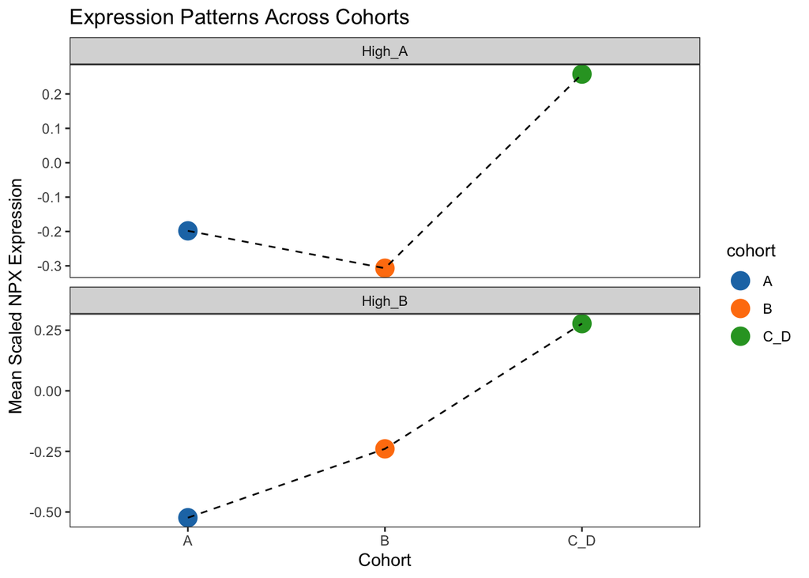

```r
# Merge with NPX dataset to keep only relevant OlinkIDs
merged_data <- dat_NPX %>%
  dplyr::select(OlinkID, NPX, cohort) %>%
  inner_join(df_high, by = "OlinkID")

# Z-score normalization per OlinkID
scaled_data <- merged_data %>%
  group_by(OlinkID) %>%
  mutate(scaled_NPX = scale(NPX)) %>%
  ungroup()

# Summarize mean NPX per cohort & contrast
summary_data <- scaled_data %>%
  group_by(category, cohort) %>%
  summarise(mean_scaled_NPX = mean(scaled_NPX), .groups = "drop")

ggplot(summary_data, aes(x = cohort, y = mean_scaled_NPX, group = category, colour = cohort)) +
  geom_point(size = 5) +  # Points
  scale_colour_manual(values=pal.cohort.n2) +
  geom_line(aes(group = category), color = "black", linetype = "dashed") +  # Connect points
  facet_wrap(~ category, scales = "free_y", nrow=2) +  # Facet by contrast
  theme_minimal() +
  labs(x = "Cohort", y = "Mean Scaled NPX Expression", title = "Expression Patterns Across Cohorts") +
  theme_custom +
  NULL
```

```r
ggsave(file=file.path(wd$outCurr, "GenePatterns.pdf"), height = 5, width = 6)
```

# 9 Obj 5: Compare the DE from methods

Extact all overexpressed mCRPC proteins

```r
cd_test <- df_de_bridge %>%
  filter(Cat %in% c("c_a_vs_cd", "c_b_vs_cd") & Adjusted_pval <= cut_fdr & log2FC >= cut_logFC) %>% pull(OlinkID) %>% unique()
cd_wilcox <- df_de_wilcox %>%
  filter(Cat %in% c("c_a_vs_cd", "c_b_vs_cd") & Adjusted_pval <= cut_fdr & log2FC >= cut_logFC) %>% pull(OlinkID) %>% unique()
cd_limma <- limma_df %>%
  filter(Contrast %in% c("A_vs_CD", "B_vs_CD")) %>%
  filter (Adjusted_pval  <= cut_fdr & log2FC >= cut_logFC) %>% pull(OlinkID) %>% unique()

overlap <- calculate.overlap(
  x <- list(
    "t_test"=cd_test,
    "Wilcox"=cd_wilcox,
    "Limma"=cd_limma))

ggvenn(
  x,
  fill_color = pal.cond3,
  show_percentage = FALSE,
  stroke_size = 0.5, set_name_size = 4
)
```

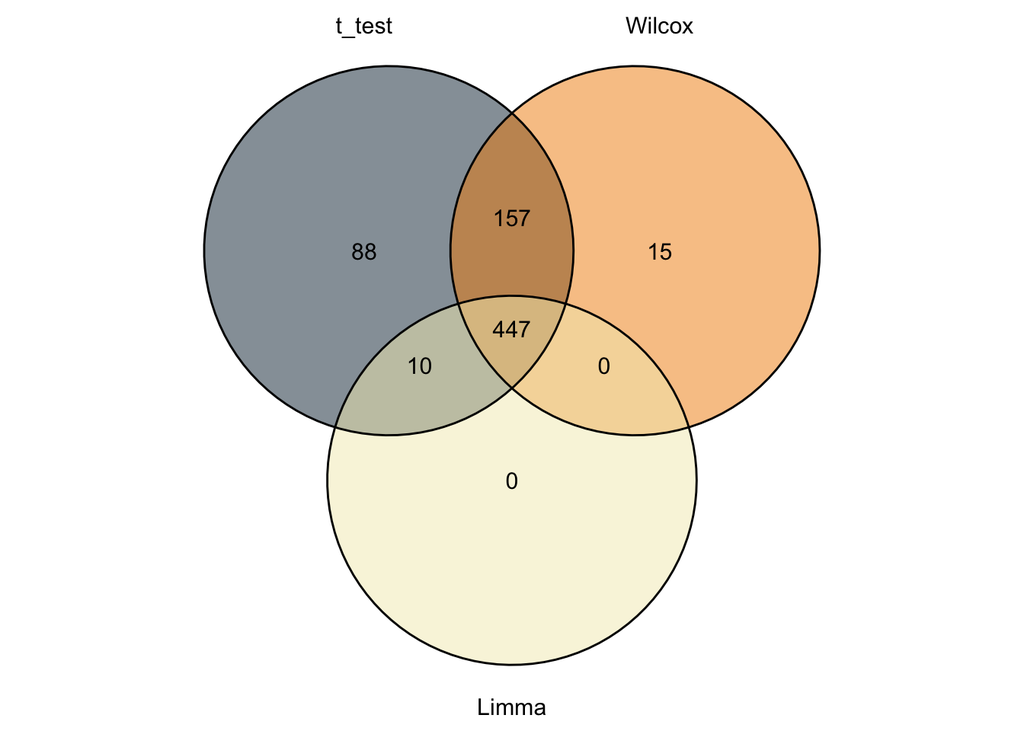

```r
pdf(file=file.path(wd$outCurr, "DE_venn_overlap_mcRPC.pdf"), width = 5, height = 5)
ggvenn(
  x,
  fill_color = pal.cond3,
  show_percentage = FALSE,
  stroke_size = 0.5, set_name_size = 4
)
dev.off()
```

Lets get the list of proteins in each of the methods

```r
# Apply the function across all elements
overlap_degree <- sapply(all_elements, function(x) get_overlap_degree(x, list("t_test" = cd_test, "wilcox" = cd_wilcox, "limma" = cd_limma)))

# Combine all lists into a single data frame
all_elements <- unique(c(cd_test, cd_wilcox, cd_limma)) # All unique elements

df_presence <- data.frame(
  OlinkID   = all_elements,
  t_test = as.integer(all_elements %in% cd_test),
  wilcox = as.integer(all_elements %in% cd_wilcox),
  limma  = as.integer(all_elements %in% cd_limma)
)  %>% left_join(df_id_pro)
write.csv(df_presence, file.path(wd$outCurr, "DE_genes_mCRPC.csv"))
```

Lets plot the top genes in each method based on the p-value

```r
t1 <- df_presence %>% filter(t_test == 1 & wilcox == 0 & limma == 0)
cd_test <- df_de_bridge %>%
  filter(Cat %in% c("c_a_vs_cd", "c_b_vs_cd") & Adjusted_pval <= cut_fdr & log2FC >= cut_logFC) %>%
  filter(OlinkID %in% t1$OlinkID) %>% slice_min(Adjusted_pval, n=5)

t1 <- df_presence %>% filter(t_test == 0 & wilcox == 1 & limma == 0)
cd_wilcox <- df_de_wilcox %>%
  filter(Cat %in% c("c_a_vs_cd", "c_b_vs_cd") & Adjusted_pval <= cut_fdr & log2FC >= cut_logFC) %>%
  filter(OlinkID %in% t1$OlinkID) %>% slice_min(Adjusted_pval, n=5)

t1 <- df_presence %>% filter(t_test == 1 & wilcox == 1 & limma == 1)
cd_limma <- limma_df %>%
  filter(Contrast %in% c("A_vs_CD", "B_vs_CD")) %>%
  filter(Adjusted_pval <= cut_fdr & log2FC >= cut_logFC) %>%
  filter(OlinkID %in% t1$OlinkID) %>% slice_min(Adjusted_pval, n=5, with_ties=FALSE)
```

Copy the plot below to power point

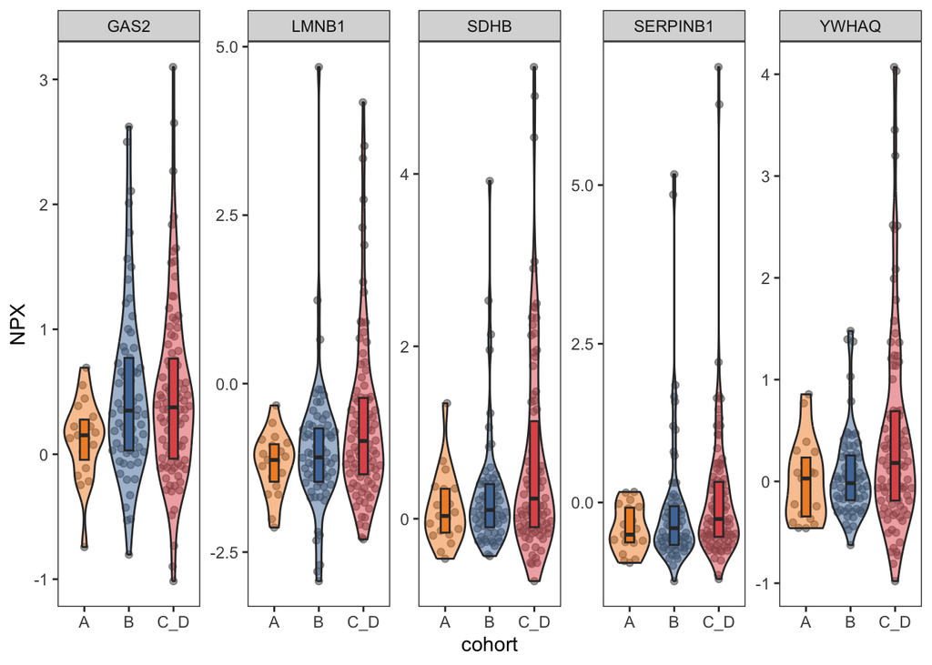

```r
df_plot <- dat_NPX %>%
  dplyr::filter(OlinkID %in% cd_test$OlinkID)  # <--- Change the subset object

# Show the plot
max_y <- max(df_plot$NPX)
min_y <- min(df_plot$NPX)

p_viol_gene <-
  df_plot %>%
  ggplot(aes(x = cohort, y = NPX, fill = cohort)) +
  geom_quasirandom(dodge.width=0.9, colour="grey30", alpha=0.5) +
  geom_violin(alpha = 0.5, scale = "width", position = position_dodge(width = 0.9)) +
  geom_boxplot(outlier.alpha = 0,  width = 0.2, coef=0,
               position = position_dodge(width = 0.9)) +
  scale_fill_manual(values=unique(pal.cohort)) +
  theme_bw() +
  theme(legend.position = "none",
        panel.grid.major = element_line(linetype = "blank"),
        panel.grid.minor = element_line(linetype = "blank"),
        axis.text.x = element_text(angle = 0)) +
  facet_wrap(~Assay, ncol=6, scales = "free_y") +
  # geom_signif(
  #   comparisons = list(c("A", "B"),
  #                      c("B", "C_D"),
  #                      c("A", "C_D")),
  #   map_signif_level = FALSE,
  #   test = "t.test",
  #   y_position = c(max_y, max_y+1, max_y+2)
  # ) +
  # scale_y_continuous(limits=c(min_y, max_y+3)) +
  NULL
p_viol_gene
```

> Stick to limma for DE

# 10 Obj 6: Overlap with surface marker

One extra thing we want to do is to overlap the mCRPC DE with known cell surfarce markers

> TO DO

# 11 Save objects

```r
save(
  meta_psom, overlap_df_limma, df_high, overlap, censor_date,
  dat1_final, assay_keep,
  limma_df, cut_fdr, cut_logFC, cd_prot,
  file = file.path(wd$outData, "02_data.Rdata"))
#save("~/Desktop/02_data.Rdata")
#load("~/Desktop/02_data.Rdata")
```